# Homework Tidyverse

Fatoumatta Demba

```r
if(!require("pacman")) install.packages("pacman")
pacman::p_load(tidyverse, gapminder, broom)
```

# Problem 1:

Copy paste and run the tribble given below.

```r
tribble( ~x,    ~y,    ~w,    ~z,
              210,   300,   220,   180,
              102,   100,   119,   187,
              176,   175,   188,   173,
              87,    95,   91,     94,
              202,   210,  234,    218,
              110,   122,  131,    128,
) -> dt
```

## 1_a:

- Use and show a `map` function to find the “mean” of each column of the `dt` data table

```r
column_means <- map_dbl(dt, mean)
print(column_means)
```

```
       x        y        w        z
147.8333 167.0000 163.8333 163.3333
```

## 1_b:

- Use and show a `map` function to find the “standard deviation” of each column of the `dt` data table.

```r
column_std <- map_dbl(dt, sd)
column_std
```

```
       x        y        w        z
54.45151 79.12016 58.40348 44.66617
```

## 1_c:

- Use and show a map function that will calculate the “square root” of each value of each column of the data table `dt`.

```r
column_square_root <- dt |>
  map_df(sqrt)
print(column_square_root)
```

```
# A tibble: 6 × 4
      x     y     w     z
  <dbl> <dbl> <dbl> <dbl>
1 14.5  17.3  14.8  13.4
2 10.1  10    10.9  13.7
3 13.3  13.2  13.7  13.2
4  9.33  9.75  9.54  9.70
5 14.2  14.5  15.3  14.8
6 10.5  11.0  11.4  11.3
```

## 1_d:

- Use R code to find the “mean”, “max”, “1st Quartile”, “3rd Quartile”, “Median”, and “Min” for each column of the `dt` data table. (Hint: You do not have to use a map function)

```r
summary(dt)
```

```
       x               y               w               z
 Min.   : 87.0   Min.   : 95.0   Min.   : 91.0   Min.   : 94.0
 1st Qu.:104.0   1st Qu.:105.5   1st Qu.:122.0   1st Qu.:139.2
 Median :143.0   Median :148.5   Median :159.5   Median :176.5
 Mean   :147.8   Mean   :167.0   Mean   :163.8   Mean   :163.3
 3rd Qu.:195.5   3rd Qu.:201.2   3rd Qu.:212.0   3rd Qu.:185.2
 Max.   :210.0   Max.   :300.0   Max.   :234.0   Max.   :218.0
```

# Problem 2:

Write a function that uses a for loop that, for each iteration, randomly draws 5 observations from an exponential distribution with “rate” parameter 1 (use `rexp()`) and calculates its “mean”. It should do this 10,000 times. Choose an appropriate plot to plot the distribution of “means”.

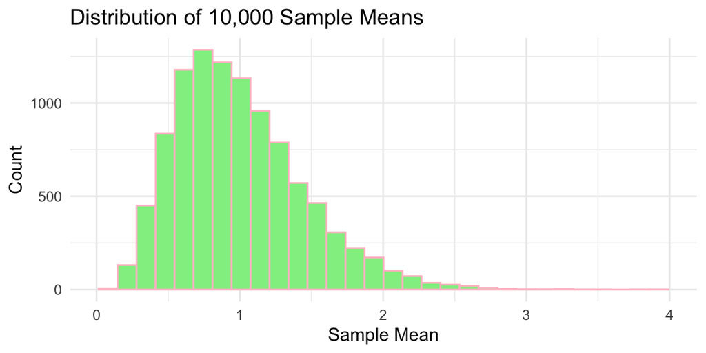

```r
sim_means <- vector(mode = 'numeric', length = 10000)
for (i in 1:10000) {
  #Randomly draws 5 observations with a rate of 1
  random_draws <- rexp(5, rate = 1)

  #Calculating the mean of those 5 observations
  sim_means[i] <- mean(random_draws)
}

#converting the results into a data frame
df_means <- data.frame(mean_values = sim_means)

  #creating a histogram from the data frame
ggplot(df_means, aes(x = mean_values)) +
    geom_histogram(fill = 'lightgreen', colour = 'pink', bins = 30) +
    labs(
    title = "Distribution of 10,000 Sample Means",
    x = "Sample Mean",
    y = "Count"
  ) +
    theme_minimal()
```

## 2_a:

- Repeat part 1 by using a `map_*()` function.

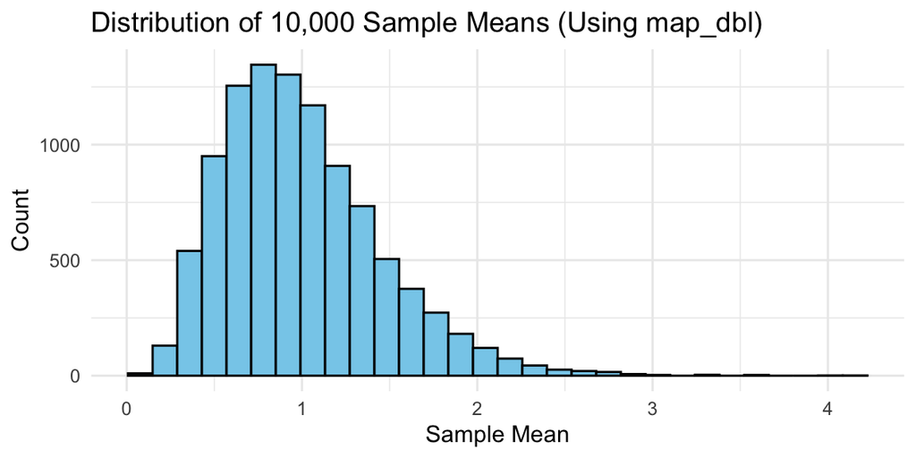

```r
# 1. Run the simulation 10,000 times using map_dbl
sim_means_map <- map_dbl(1:10000, ~ mean(rexp(5, rate = 1)))

# 2. Convert the vector to a data frame for ggplot2
df_means_map <- data.frame(mean_values = sim_means_map)

# 3. Generate the histogram plot
ggplot(df_means_map, aes(x = mean_values)) +
  geom_histogram(fill = "skyblue", color = "black", bins = 30) +
  labs(
    title = "Distribution of 10,000 Sample Means (Using map_dbl)",
    x = "Sample Mean",
    y = "Count"
  ) +
  theme_minimal()
```

## 2_b:

- Repeat part 1 by using the `replicate()` function.

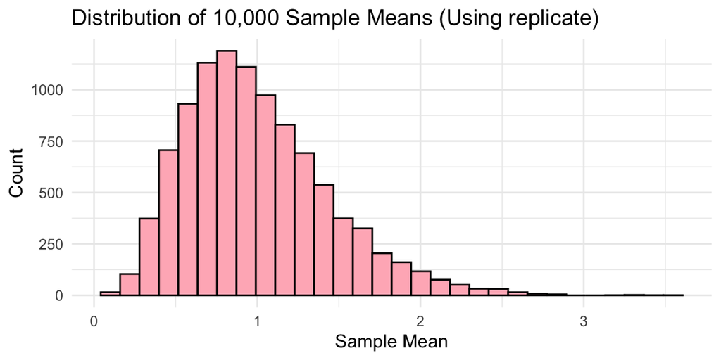

```r
# 1. Run the simulation 10,000 times using replicate
sim_means_rep <- replicate(10000, mean(rexp(5, rate = 1)))

# 2. Convert the vector to a data frame for ggplot2
df_means_rep <- data.frame(mean_values = sim_means_rep)

# 3. Generate the histogram plot
ggplot(df_means_rep, aes(x = mean_values)) +
  geom_histogram(fill = "lightpink", color = "black", bins = 30) +
  labs(
    title = "Distribution of 10,000 Sample Means (Using replicate)",
    x = "Sample Mean",
    y = "Count"
  ) +
  theme_minimal()
```

## 2_c:

- Use a another for loop that will print out plots for sample sizes of 5, 10, and 20 observations (instead of just 5).

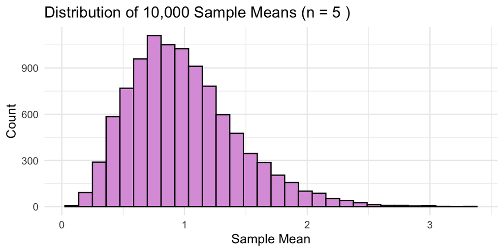

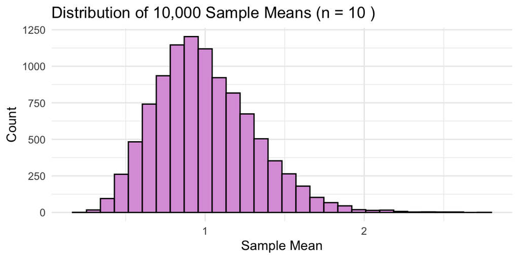

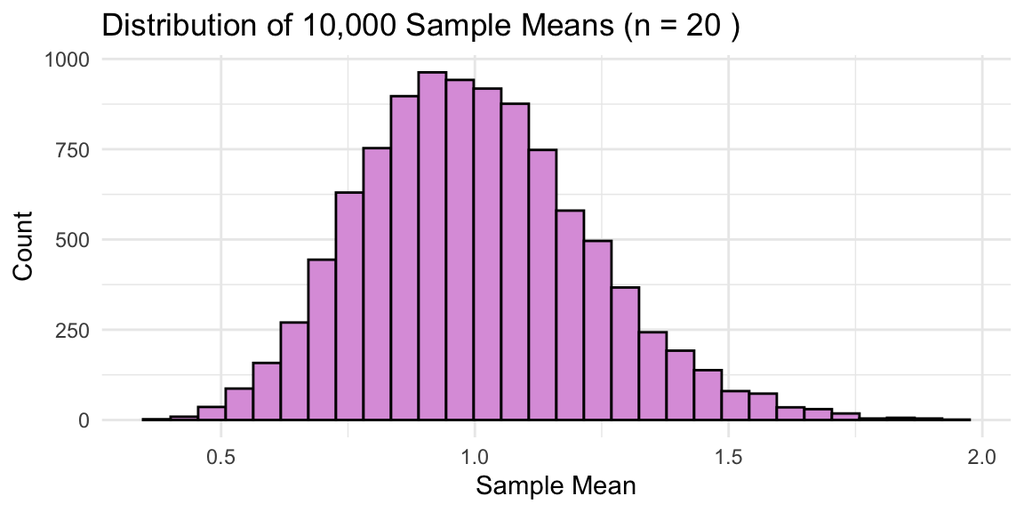

```r
sample_sizes <- c(5, 10, 20)
# Run a loop where 'n' takes the value of 5, then 10, then 20
for (n in sample_sizes) {

  # 1. Run the simulation 10,000 times using the current sample size 'n'
  sim_means <- replicate(10000, mean(rexp(n, rate = 1)))

  # 2. Put the vector into a temporary data frame for plotting
  df_temp <- data.frame(mean_values = sim_means)

  # 3. Create the histogram plot
  p <- ggplot(df_temp, aes(x = mean_values)) +
    geom_histogram(fill = "plum", color = "black", bins = 30) +
    labs(
      title = paste("Distribution of 10,000 Sample Means (n =", n, ")"),
      x = "Sample Mean",
      y = "Count"
    ) +
    theme_minimal()

  # 4. CRITICAL: Inside a for loop, you must explicitly print() the plot
  print(p)
}
```

# Problem 3:

- Use and show R coding to calculate the “standard deviation” for each variable of the data table `mtcars` using the “Special For Loop Method”.

**Note:**

- There are two methods. Please see a quick explanation for both methods in below:
  - Method 1:

```r
  multi_return <- function() {
    my_list <- list("color" = "red", "size" = 20, "shape" = "round")
    return(my_list)
  }
```

```r
a <- multi_return()
a$color
```

```
[1] "red"
```

```r
a<- multi_return()
a$shape
```

```
[1] "round"
```

```r
a<- multi_return()
a$size
```

```
[1] 20
```

- Method 2. The “Special For Loop Method”

```r
output <- vector("double", ncol(df))  # 1. output (use appropriate data frame instead of df)
for (i in seq_along(df)) {            # 2. sequence
  output[[i]] <- median(df[[i]])      # 3. body
}
output
```

- **Solution:** coding to calculate the “standard deviation” for each variable

```r
sd_results <- vector(mode = "numeric", length = ncol(mtcars))

# 2. Assign names to the vector positions so you know which column is which
names(sd_results) <- colnames(mtcars)

# 3. Run the for loop over every column index
for (i in 1:ncol(mtcars)) {
  # Calculate the standard deviation for column 'i' and save it in position 'i'
  sd_results[i] <- sd(mtcars[[i]])
}

# 4. Print the final calculated values
print(sd_results)
```

```
        mpg         cyl        disp          hp        drat          wt
  6.0269481   1.7859216 123.9386938  68.5628685   0.5346787   0.9784574
       qsec          vs          am        gear        carb
  1.7869432   0.5040161   0.4989909   0.7378041   1.6152000
```

# Problem 4:

Generate a sequence of dates from **January 1, 2015** to **December 31, 2025**, spaced by every **two months**. Extract the **year**, **quarter**, and **ISO week number** for each date.

```r
library(lubridate)

date_seq <- seq(from = as.Date("2015-01-01"),
                to = as.Date("2025-12-31"),
                by = "2 months")

date_breakdown <- data.frame(
  Original_Date = date_seq,
  Year = year(date_seq),
  Quarter = quarter(date_seq),
  ISO_Week = isoweek(date_seq)
)

head(date_breakdown, 10)
```

```
   Original_Date Year Quarter ISO_Week
1     2015-01-01 2015       1        1
2     2015-03-01 2015       1        9
3     2015-05-01 2015       2       18
4     2015-07-01 2015       3       27
5     2015-09-01 2015       3       36
6     2015-11-01 2015       4       44
7     2016-01-01 2016       1       53
8     2016-03-01 2016       1        9
9     2016-05-01 2016       2       17
10    2016-07-01 2016       3       26
```

# Problem 5

Given the following dates, compute the difference in **months** and **weeks** between each consecutive pair.

```r
sample_dates <- c("2018-03-15", "2020-07-20", "2023-01-10", "2025-09-05")

date_objects <- as.Date(sample_dates)
weeks_diff <- diff(date_objects) / 7

intervals <- interval(start = date_objects [-length(date_objects)], end = date_objects[-1])

months_diff <- time_length(intervals, unit = "month")

gaps_table <- data.frame(
  From = sample_dates[-length(sample_dates)],
  To = sample_dates[-1],
  Diff_Weeks = round(as.numeric(weeks_diff), 2),
  Diff_Months = round(months_diff, 2)
)

print(gaps_table)
```

```
        From         To Diff_Weeks Diff_Months
1 2018-03-15 2020-07-20     122.57       28.16
2 2020-07-20 2023-01-10     129.14       29.68
3 2023-01-10 2025-09-05     138.43       31.84
```

# Problem 6

Given a list of mixed date formats, use `map()` and `possibly()` from `purrr` to safely convert them to **Date** format and extract the **month name**.

```r
library(purrr)
date_strings <- list("2023-06-10", "2022/12/25", "15-Aug-2021", "InvalidDate")

get_month_native <- function(x) {
  # suppressWarnings hides the "failed to parse" text for InvalidDate
  parsed_date <- suppressWarnings(parse_date_time(x, orders = c("ymd", "ydm", "dmy")))

  # label = TRUE and abbr = FALSE forces the full text string output
  as.character(month(parsed_date, label = TRUE, abbr = FALSE))
}

safe_month_extractor <- possibly(get_month_native, otherwise = NA_character_)

# map_chr forces a clean character vector output directly
month_names <- map_chr(date_strings, safe_month_extractor)

result_table <- data.frame(
  Input_String = unlist(date_strings),
  Month_Name   = month_names
)

print(result_table)
```

```
  Input_String Month_Name
1   2023-06-10       June
2   2022/12/25   December
3  15-Aug-2021     August
4  InvalidDate       <NA>
```